In this notebook, we will explore some common applications of vector norms in data science. It’s essential to recognize that the potential uses of vector norms are limited only by our imagination—they can be applied in countless ways across various projects.

Additionally, we will demonstrate how to calculate Linear Regression using vectors and matrices, rather than relying solely on the Scikit-Learn library function.

To summarize, we’ll begin by examining the role of vector norms as regularizers in predictive algorithms, and then we'll discuss how they are used to evaluate the accuracy of regression models by measuring error.

# Regularization

In this section, we will explore how vector norms play a crucial role in three different algorithms that use them as a penalty term. To illustrate this, we will use the Diabetes dataset, which can be downloaded from Scikit-Learn.

## Input

```python
import numpy as np
import pandas as pd
from tqdm import tqdm
from sklearn.datasets import load_diabetes

data = load_diabetes()
df = pd.concat([
        pd.DataFrame(data.data),
        pd.DataFrame(data.target)],
           axis=1)
df.columns = data.feature_names + ['y']
df.head()
```

|  | age | sex | bmi | bp | s1 | s2 | s3 | s4 | s5 | s6 | y |
| --- | --- | --- | --- | --- | --- | --- | --- | --- | --- | --- | --- |
| 0 | 0.038076 | 0.050680 | 0.061696 | 0.021872 | -0.044223 | -0.034821 | -0.043401 | -0.002592 | 0.019907 | -0.017646 | 151.0 |
| 1 | -0.001882 | -0.044642 | -0.051474 | -0.026328 | -0.008449 | -0.019163 | 0.074412 | -0.039493 | -0.068332 | -0.092204 | 75.0 |
| 2 | 0.085299 | 0.050680 | 0.044451 | -0.005670 | -0.045599 | -0.034194 | -0.032356 | -0.002592 | 0.002861 | -0.025930 | 141.0 |
| 3 | -0.089063 | -0.044642 | -0.011595 | -0.036656 | 0.012191 | 0.024991 | -0.036038 | 0.034309 | 0.022688 | -0.009362 | 206.0 |
| 4 | 0.005383 | -0.044642 | -0.036385 | 0.021872 | 0.003935 | 0.015596 | 0.008142 | -0.002592 | -0.031988 | -0.046641 | 135.0 |

Here we can see that the dataset doesn't need further preprocessing because columns are already numeric and standardized so it can be assumed that's ok to use directly without checking for outliers or NAs as it's a toy dataset made for this kind of purposes.

## Output

Next, we will examine the impact of varying the regularization parameter in predictive models that use vector norms for this purpose. The regularization term acts as a penalty in the algorithm's optimization function, guiding it toward a unique optimal solution.

The models we'll explore are LASSO, Ridge, and ElasticNet. LASSO uses the L1 norm as a penalty in its cost function, encouraging solutions where many of the model's parameters are set to zero. Ridge employs the L2 norm, which promotes solutions with smaller parameter values. ElasticNet combines both the L1 and L2 norms.

LASSO uses the mean square error (MSE) along with a penalty term, $\lambda$, for L1 regularization:

$C = \frac{1}{N} \displaystyle\sum_{i=1}^{N} (y_i - \hat{y_i})^2 + \lambda \displaystyle\sum_{j=1}^{m} |w_j|$

Ridge also uses MSE, but with $\lambda$ for L2 regularization:

$C = \frac{1}{N} \displaystyle\sum_{i=1}^{N} (y_i - \hat{y_i})^2 + \lambda \displaystyle\sum_{j=1}^{m} |w_j|^2$

ElasticNet incorporates both L1 and L2 regularization, using a parameter $\alpha$ to balance their contributions:

$C = \frac{1}{N} \displaystyle\sum_{i=1}^{N} (y_i - \hat{y_i})^2 + \lambda \lbrack \alpha \displaystyle\sum_{j=1}^{m} |w_j| + (1 - \alpha) \displaystyle\sum_{j=1}^{m} |w_j|^2 \rbrack$

We will run each algorithm 10 times to observe the effect of varying $\lambda$ from 0.01 to 1.09. The results will be represented in 10 different plots, arranged side by side, for each model. Each plot will include a vertical line indicating the point of minimum error.

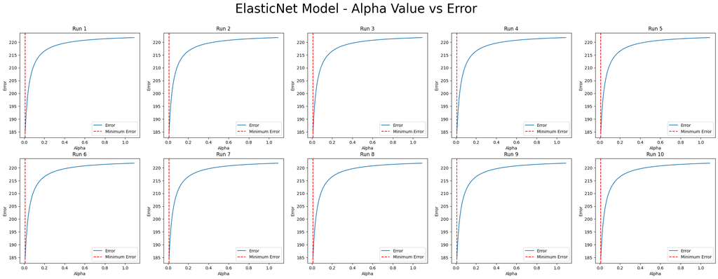

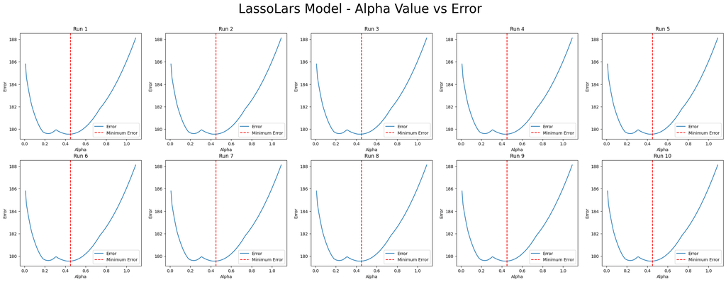

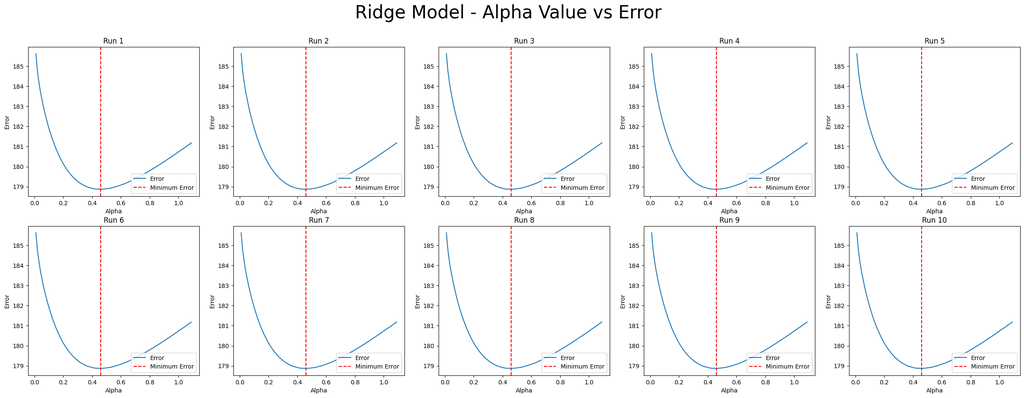

```python
from sklearn.model_selection import train_test_split
from sklearn.linear_model import ElasticNet, LassoLars, Ridge

from matplotlib import pyplot as plt

def plot_model_performance(model_class, model_name):
    """
    Evaluate and plot the performance of a given regression model over a range of alpha values.

    Parameters:
    - model_class: The regression model class (e.g., ElasticNet, LassoLars, Ridge).
    - model_name: A string name for the model to be used in the plot title.
    """

    def compute_p_norm(vector, p):
        """
        Compute the p-norm of a vector.

        Parameters:
        - vector: The input vector.
        - p: The norm order (e.g., 1 for L1 norm, 2 for L2 norm).

        Returns:
        - The p-norm of the vector.
        """
        return np.sum(np.abs(vector) ** p) ** (1 / p)

    plt.figure(figsize=(30, 10))

    for i in range(10):
        # Load and split the diabetes dataset
        data = load_diabetes()
        X, y = data.data, data.target
        X_train, X_test, y_train, y_test = train_test_split(X, y, test_size=0.2, random_state=42)

        # Dictionary to hold predictions for different alpha values
        predictions = {}

        # Evaluate model performance for a range of alpha values
        for alpha in np.arange(0.01, 1.1, 0.01):
            model = model_class(alpha=alpha)
            model_fit = model.fit(X_train, y_train)
            predictions[str(alpha)] = model_fit.predict(X_test)

        # Calculate errors for each alpha value
        errors = []
        for alpha_str, pred in predictions.items():
            alpha_value = float(alpha_str)
            error = compute_p_norm(pred - y_test, p=5)
            errors.append((round(alpha_value, 2), round(error, 2)))

        # Convert errors to a DataFrame for easy manipulation
        errors_df = pd.DataFrame(errors, columns=['Alpha', 'Error'])
        best_alpha = errors_df.sort_values('Error').iloc[0]['Alpha']

        # Plot the performance
        plt.subplot(2, 5, i + 1)
        plt.plot(errors_df['Alpha'], errors_df['Error'], label='Error')
        plt.axvline(x=best_alpha, color='r', linestyle='--', label='Minimum Error')
        plt.legend(loc='lower right')
        plt.xlabel('Alpha')
        plt.ylabel('Error')
        plt.title(f'Run {i + 1}')

    plt.suptitle(f"{model_name} Model - Alpha Value vs Error", fontsize=30)
    plt.show()

# List of models and their names
models = [ElasticNet, LassoLars, Ridge]
names = ['ElasticNet', 'LassoLars', 'Ridge']

# Evaluate and plot each model
for model, name in zip(models, names):
    plot_model_performance(model_class=model, model_name=name)
```

Selecting the correct regularization parameter is crucial for each model to avoid over-penalization and achieve the best possible predictive performance. Therefore, depending on the model that we are choosing we have to use a different value for this purpose.

# Error

In this section, we will use five different datasets to illustrate the impact of various vector norms. It is important to consider the unit of measurement in each dataset for accurate comparison.

The datasets we will use are:

- Market Arrivals, which is use to predict the quantity of people arriving at markets.
- Mall Customers, which is use to predict the spending scores of customers.
- Life Expectancy, which is use to predict the life expectancy of people.
- Car, which is use to predict the sales of cars.
- and College, which is use to predict students rates.

All of them were downloaded from https://github.com/selva86

## Datasets

```python
# downloading data
url = "https://raw.githubusercontent.com/selva86/datasets/master/"
datasets = [
    'MarketArrivals',
    'Mall_Customers_Int',
    'Life_Expectancy_Data',
    'Carseats',
    'College']
data = {}
for dataset in datasets:
    data[dataset] = pd.read_csv(url + dataset + ".csv")
```

```python
data['MarketArrivals'].head()
```

|  | market | month | year | quantity | priceMin | priceMax | priceMod | state | city | date |
| --- | --- | --- | --- | --- | --- | --- | --- | --- | --- | --- |
| 0 | ABOHAR(PB) | January | 2005 | 2350 | 404 | 493 | 446 | PB | ABOHAR | January-2005 |
| 1 | ABOHAR(PB) | January | 2006 | 900 | 487 | 638 | 563 | PB | ABOHAR | January-2006 |
| 2 | ABOHAR(PB) | January | 2010 | 790 | 1283 | 1592 | 1460 | PB | ABOHAR | January-2010 |
| 3 | ABOHAR(PB) | January | 2011 | 245 | 3067 | 3750 | 3433 | PB | ABOHAR | January-2011 |
| 4 | ABOHAR(PB) | January | 2012 | 1035 | 523 | 686 | 605 | PB | ABOHAR | January-2012 |

```python
data['Mall_Customers_Int'].head()
```

|  | CustomerID | Genre | Age | Annual_Income_(k$) | Spending_Score |
| --- | --- | --- | --- | --- | --- |
| 0 | 1 | 1 | 19.0 | 15.0 | 39.0 |
| 1 | 2 | 1 | 21.0 | 15.0 | 81.0 |
| 2 | 3 | 0 | 20.0 | 16.0 | 6.0 |
| 3 | 4 | 0 | 23.0 | 16.0 | 77.0 |
| 4 | 5 | 0 | 31.0 | 17.0 | 40.0 |

```python
data['Life_Expectancy_Data'].head()
```

|  | Country | Year | Status | Life expectancy | Adult Mortality | infant deaths | Alcohol | percentage expenditure | Hepatitis B | Measles | ... | Polio | Total expenditure | Diphtheria | HIV/AIDS | GDP | Population | thinness 1-19 years | thinness 5-9 years | Income composition of resources | Schooling |
| --- | --- | --- | --- | --- | --- | --- | --- | --- | --- | --- | --- | --- | --- | --- | --- | --- | --- | --- | --- | --- | --- |
| 0 | Afghanistan | 2015 | Developing | 65.0 | 263 | 62 | 0.01 | 71.279624 | 65 | 1154 | ... | 6 | 8.16 | 65 | 0.1 | 584.259210 | 33736494.0 | 17.2 | 17.3 | 0.479 | 10.1 |
| 1 | Afghanistan | 2014 | Developing | 59.9 | 271 | 64 | 0.01 | 73.523582 | 62 | 492 | ... | 58 | 8.18 | 62 | 0.1 | 612.696514 | 327582.0 | 17.5 | 17.5 | 0.476 | 10.0 |
| 2 | Afghanistan | 2013 | Developing | 59.9 | 268 | 66 | 0.01 | 73.219243 | 64 | 430 | ... | 62 | 8.13 | 64 | 0.1 | 631.744976 | 31731688.0 | 17.7 | 17.7 | 0.470 | 9.9 |
| 3 | Afghanistan | 2012 | Developing | 59.5 | 272 | 69 | 0.01 | 78.184215 | 67 | 2787 | ... | 67 | 8.52 | 67 | 0.1 | 669.959000 | 3696958.0 | 17.9 | 18.0 | 0.463 | 9.8 |
| 4 | Afghanistan | 2011 | Developing | 59.2 | 275 | 71 | 0.01 | 7.097109 | 68 | 3013 | ... | 68 | 7.87 | 68 | 0.1 | 63.537231 | 2978599.0 | 18.2 | 18.2 | 0.454 | 9.5 |

5 rows × 22 columns

```python
data['Carseats'].head()
```

|  | Sales | CompPrice | Income | Advertising | Population | Price | ShelveLoc | Age | Education | Urban | US |
| --- | --- | --- | --- | --- | --- | --- | --- | --- | --- | --- | --- |
| 0 | 9.50 | 138 | 73 | 11 | 276 | 120 | Bad | 42 | 17 | Yes | Yes |
| 1 | 11.22 | 111 | 48 | 16 | 260 | 83 | Good | 65 | 10 | Yes | Yes |
| 2 | 10.06 | 113 | 35 | 10 | 269 | 80 | Medium | 59 | 12 | Yes | Yes |
| 3 | 7.40 | 117 | 100 | 4 | 466 | 97 | Medium | 55 | 14 | Yes | Yes |
| 4 | 4.15 | 141 | 64 | 3 | 340 | 128 | Bad | 38 | 13 | Yes | No |

```python
data['College'].head()
```

|  | Private | Apps | Accept | Enroll | Top10perc | Top25perc | F.Undergrad | P.Undergrad | Outstate | Room.Board | Books | Personal | PhD | Terminal | S.F.Ratio | perc.alumni | Expend | Grad.Rate |
| --- | --- | --- | --- | --- | --- | --- | --- | --- | --- | --- | --- | --- | --- | --- | --- | --- | --- | --- |
| 0 | Yes | 1660 | 1232 | 721 | 23 | 52 | 2885 | 537 | 7440 | 3300 | 450 | 2200 | 70 | 78 | 18.1 | 12 | 7041 | 60 |
| 1 | Yes | 2186 | 1924 | 512 | 16 | 29 | 2683 | 1227 | 12280 | 6450 | 750 | 1500 | 29 | 30 | 12.2 | 16 | 10527 | 56 |
| 2 | Yes | 1428 | 1097 | 336 | 22 | 50 | 1036 | 99 | 11250 | 3750 | 400 | 1165 | 53 | 66 | 12.9 | 30 | 8735 | 54 |
| 3 | Yes | 417 | 349 | 137 | 60 | 89 | 510 | 63 | 12960 | 5450 | 450 | 875 | 92 | 97 | 7.7 | 37 | 19016 | 59 |
| 4 | Yes | 193 | 146 | 55 | 16 | 44 | 249 | 869 | 7560 | 4120 | 800 | 1500 | 76 | 72 | 11.9 | 2 | 10922 | 15 |

From these dataframes, the minimum preprocessing required for predictive use includes:

## Preprocessing

```python
scaler = lambda x: (x - min(x)) / (max(x) - min(x))
encoder = lambda x: dict(zip(
    x.unique(),
    range(x.nunique())
))

for key in tqdm(list(data.keys())):
  data[key].dropna(inplace = True) # dropping null values
  for col in data[key].columns:
    cols = data[key].columns
    if data[key][col].dtype == 'O': # discretizing categorical columns
      data[key][col] = data[key][col].map(encoder(data[key][col]))
    data[key][col] = scaler(data[key][col]) # scaling columns
```

```python
data['MarketArrivals'].head()
```

|  | market | month | year | quantity | priceMin | priceMax | priceMod | state | city | date |
| --- | --- | --- | --- | --- | --- | --- | --- | --- | --- | --- |
| 0 | 0.0 | 0.0 | 0.45 | 0.001422 | 0.064840 | 0.043246 | 0.057911 | 0.0 | 0.0 | 0.000000 |
| 1 | 0.0 | 0.0 | 0.50 | 0.000537 | 0.078710 | 0.061265 | 0.076424 | 0.0 | 0.0 | 0.004149 |
| 2 | 0.0 | 0.0 | 0.70 | 0.000470 | 0.211731 | 0.179819 | 0.218354 | 0.0 | 0.0 | 0.008299 |
| 3 | 0.0 | 0.0 | 0.75 | 0.000137 | 0.509860 | 0.447993 | 0.530538 | 0.0 | 0.0 | 0.012448 |
| 4 | 0.0 | 0.0 | 0.80 | 0.000619 | 0.084726 | 0.067230 | 0.083070 | 0.0 | 0.0 | 0.016598 |

```python
data['Mall_Customers_Int'].head()
```

|  | CustomerID | Genre | Age | Annual_Income_(k$) | Spending_Score |
| --- | --- | --- | --- | --- | --- |
| 0 | 0.000000 | 1.0 | 0.019231 | 0.000000 | 0.387755 |
| 1 | 0.005025 | 1.0 | 0.057692 | 0.000000 | 0.816327 |
| 2 | 0.010050 | 0.0 | 0.038462 | 0.008197 | 0.051020 |
| 3 | 0.015075 | 0.0 | 0.096154 | 0.008197 | 0.775510 |
| 4 | 0.020101 | 0.0 | 0.250000 | 0.016393 | 0.397959 |

```python
data['Life_Expectancy_Data'].head()
```

|  | Country | Year | Status | Life expectancy | Adult Mortality | infant deaths | Alcohol | percentage expenditure | Hepatitis B | Measles | ... | Polio | Total expenditure | Diphtheria | HIV/AIDS | GDP | Population | thinness 1-19 years | thinness 5-9 years | Income composition of resources | Schooling |
| --- | --- | --- | --- | --- | --- | --- | --- | --- | --- | --- | --- | --- | --- | --- | --- | --- | --- | --- | --- | --- | --- |
| 0 | 0.0 | 1.000000 | 0.0 | 0.466667 | 0.362881 | 0.038750 | 0.0 | 0.003759 | 0.649485 | 0.008780 | ... | 0.031250 | 0.543590 | 0.649485 | 0.0 | 0.004889 | 0.026074 | 0.630996 | 0.612100 | 0.511752 | 0.357576 |
| 1 | 0.0 | 0.933333 | 0.0 | 0.353333 | 0.373961 | 0.040000 | 0.0 | 0.003878 | 0.618557 | 0.003743 | ... | 0.572917 | 0.545055 | 0.618557 | 0.0 | 0.005127 | 0.000253 | 0.642066 | 0.619217 | 0.508547 | 0.351515 |
| 2 | 0.0 | 0.866667 | 0.0 | 0.353333 | 0.369806 | 0.041250 | 0.0 | 0.003861 | 0.639175 | 0.003271 | ... | 0.614583 | 0.541392 | 0.639175 | 0.0 | 0.005287 | 0.024525 | 0.649446 | 0.626335 | 0.502137 | 0.345455 |
| 3 | 0.0 | 0.800000 | 0.0 | 0.344444 | 0.375346 | 0.043125 | 0.0 | 0.004123 | 0.670103 | 0.021203 | ... | 0.666667 | 0.569963 | 0.670103 | 0.0 | 0.005608 | 0.002857 | 0.656827 | 0.637011 | 0.494658 | 0.339394 |
| 4 | 0.0 | 0.733333 | 0.0 | 0.337778 | 0.379501 | 0.044375 | 0.0 | 0.000374 | 0.680412 | 0.022923 | ... | 0.677083 | 0.522344 | 0.680412 | 0.0 | 0.000519 | 0.002302 | 0.667897 | 0.644128 | 0.485043 | 0.321212 |

5 rows × 22 columns

```python
data['Carseats'].head()
```

|  | Sales | CompPrice | Income | Advertising | Population | Price | ShelveLoc | Age | Education | Urban | US |
| --- | --- | --- | --- | --- | --- | --- | --- | --- | --- | --- | --- |
| 0 | 0.583897 | 0.622449 | 0.525253 | 0.379310 | 0.533066 | 0.574850 | 0.0 | 0.309091 | 0.875 | 0.0 | 0.0 |
| 1 | 0.689613 | 0.346939 | 0.272727 | 0.551724 | 0.501002 | 0.353293 | 0.5 | 0.727273 | 0.000 | 0.0 | 0.0 |
| 2 | 0.618316 | 0.367347 | 0.141414 | 0.344828 | 0.519038 | 0.335329 | 1.0 | 0.618182 | 0.250 | 0.0 | 0.0 |
| 3 | 0.454825 | 0.408163 | 0.797980 | 0.137931 | 0.913828 | 0.437126 | 1.0 | 0.545455 | 0.500 | 0.0 | 0.0 |
| 4 | 0.255071 | 0.653061 | 0.434343 | 0.103448 | 0.661323 | 0.622754 | 0.0 | 0.236364 | 0.375 | 0.0 | 1.0 |

```python
data['College'].head()
```

|  | Private | Apps | Accept | Enroll | Top10perc | Top25perc | F.Undergrad | P.Undergrad | Outstate | Room.Board | Books | Personal | PhD | Terminal | S.F.Ratio | perc.alumni | Expend | Grad.Rate |
| --- | --- | --- | --- | --- | --- | --- | --- | --- | --- | --- | --- | --- | --- | --- | --- | --- | --- | --- |
| 0 | 0.0 | 0.032887 | 0.044177 | 0.107913 | 0.231579 | 0.472527 | 0.087164 | 0.024548 | 0.263430 | 0.239596 | 0.157754 | 0.297710 | 0.652632 | 0.710526 | 0.418231 | 0.187500 | 0.072671 | 0.462963 |
| 1 | 0.0 | 0.043842 | 0.070531 | 0.075035 | 0.157895 | 0.219780 | 0.080752 | 0.056148 | 0.513430 | 0.736129 | 0.291444 | 0.190840 | 0.221053 | 0.078947 | 0.260054 | 0.250000 | 0.138387 | 0.425926 |
| 2 | 0.0 | 0.028055 | 0.039036 | 0.047349 | 0.221053 | 0.450549 | 0.028473 | 0.004488 | 0.460227 | 0.310530 | 0.135472 | 0.139695 | 0.473684 | 0.552632 | 0.278820 | 0.468750 | 0.104605 | 0.407407 |
| 3 | 0.0 | 0.006998 | 0.010549 | 0.016045 | 0.621053 | 0.879121 | 0.011776 | 0.002839 | 0.548554 | 0.578499 | 0.157754 | 0.095420 | 0.884211 | 0.960526 | 0.139410 | 0.578125 | 0.298415 | 0.453704 |
| 4 | 0.0 | 0.002333 | 0.002818 | 0.003146 | 0.157895 | 0.384615 | 0.003492 | 0.039753 | 0.269628 | 0.368852 | 0.313725 | 0.190840 | 0.715789 | 0.631579 | 0.252011 | 0.031250 | 0.145833 | 0.046296 |

Now that the data is prepared, we can proceed to analyze the effect of each error measure on these datasets. For this analysis, we will use the Linear Regression function from Scikit-Learn.

We will evaluate the following error measures:

- Max Error: $MAX = max_i(|x|_i)$
- Mean Absolute Error: $MAE = \frac{1}{N} \displaystyle\sum_{i=1}^{N} |y_i - \hat{y_i}|$
- Mean Square Error: $MSE = \frac{1}{N} \displaystyle\sum_{i=1}^{N} (y_i - \hat{y_i})^2$
- Root Square Mean Error: $RMSE = \sqrt{\frac{1}{N} \displaystyle\sum_{i=1}^{N} (y_i - \hat{y_i})^2}$
- Mean Absolute Percentage Error: $MAPE = \frac{1}{N} \displaystyle\sum_{i=1}^{N} \frac{|y_i - \hat{y_i}|}{y_i}$
- R Squared: $R^2 = 1 - \frac{\displaystyle\sum_{i=1}^{N}(y_i - \hat{y_i})^2}{\displaystyle\sum_{i=1}^{N}(y_i - \bar{y_i})^2}$
- Adjusted R Squared: $R^2_{adj} = 1 - \frac{(1-R^2)(N-1)}{N-k-1}$

```python
from prettytable import PrettyTable
from sklearn.linear_model import LinearRegression

max_norm = lambda x: np.max(x)
mean_squared_error = lambda x: np.mean(x ** 2)
p_norm = lambda x, p: np.sum(np.abs(x) ** p) ** (1 / p)
coefficient_of_determination = lambda true, pred: 1 - (np.sum((true - pred) ** 2) / np.sum((true - np.mean(true)) ** 2))
adjusted_r2 = lambda true, pred, k: 1 - (((len(true) - 1) / (len(true) - k - 1)) * (1 - (1 - (np.sum((true - pred) ** 2) / np.sum((true - np.mean(true)) ** 2)))))

error_cols = ['label', 'max', 'mae', 'rmse', 'mape', 'mse', 'r2', 'r2adj']
labels = ['quantity', 'Spending_Score', 'Life expectancy ', 'Sales', 'Grad.Rate'] # variables to predict
for j in range(3):
    lr, errors = LinearRegression(), [] # model
    for dataset, label in zip(datasets, labels):
        X, y = data[dataset].drop(label, axis = 1), data[dataset][label] # partitioning
        k = X.shape[1]
        X_train, X_test, y_train, y_test = train_test_split(X, y, test_size = 0.2)
        preds = lr.fit(X_train, y_train).predict(X_test) # modeling and predicting
        # calculating errors
        max_   = max_norm(x = y_test - preds)
        mae    = p_norm(x = y_test - preds, p = 1)
        rmse   = p_norm(x = y_test - preds, p = 2)
        mape   = p_norm(x = abs(y_test - preds) / y_test, p = 1)
        mse_   = mean_squared_error(x = y_test - preds)
        r2_    = coefficient_of_determination(true = y_test, pred = preds)
        r2adj_ = adjusted_r2(true = y_test, pred = preds, k = k)
        errors.append((dataset, max_, mae, rmse, mape, mse_, r2_, r2adj_)) # storing errors
    errors = pd.DataFrame(errors, columns = error_cols).set_index('label').replace((-np.inf, +np.inf), (0 ,0))

    x = PrettyTable()
    x.field_names = error_cols
    for row, i in zip(errors.index, range(errors.shape[0])):
        x.add_row([
            errors.index[i].upper(),
            round(errors.loc[row, error_cols[1]] * 100),
            round(errors.loc[row, error_cols[2]] * 100),
            round(errors.loc[row, error_cols[3]] * 100),
            round(errors.loc[row, error_cols[4]] * 100),
            round(errors.loc[row, error_cols[5]] * 100),
            round(errors.loc[row, error_cols[6]] * 100),
            round(errors.loc[row, error_cols[7]] * 100)
        ])
    print(f"\nRun Number {j+1}")
    print(x)
```

```
Run Number 1
+----------------------+-----+------+------+----------+-----+----+-------+
|        label         | max | mae  | rmse |   mape   | mse | r2 | r2adj |
+----------------------+-----+------+------+----------+-----+----+-------+
|    MARKETARRIVALS    |  81 | 9950 | 342  | 13041020 |  1  | 2  |   2   |
|  MALL_CUSTOMERS_INT  |  48 | 962  | 184  |    0     |  9  | -1 |  -13  |
| LIFE_EXPECTANCY_DATA |  22 | 1989 | 142  |   4949   |  1  | 81 |   80  |
|       CARSEATS       |  28 | 686  |  99  |   1817   |  1  | 60 |   54  |
|       COLLEGE        |  22 | 1202 | 129  |   3751   |  1  | 56 |   51  |
+----------------------+-----+------+------+----------+-----+----+-------+

Run Number 2
+----------------------+-----+------+------+----------+-----+----+-------+
|        label         | max | mae  | rmse |   mape   | mse | r2 | r2adj |
+----------------------+-----+------+------+----------+-----+----+-------+
|    MARKETARRIVALS    |  95 | 9944 | 358  | 11177133 |  1  | 3  |   2   |
|  MALL_CUSTOMERS_INT  |  44 | 747  | 149  |   3322   |  6  | 1  |  -11  |
| LIFE_EXPECTANCY_DATA |  28 | 2188 | 159  |   6577   |  1  | 79 |   78  |
|       CARSEATS       |  29 | 704  | 100  |   1749   |  1  | 50 |   43  |
|       COLLEGE        |  34 | 1566 | 163  |    0     |  2  | 39 |   31  |
+----------------------+-----+------+------+----------+-----+----+-------+

Run Number 3
+----------------------+-----+------+------+---------+-----+----+-------+
|        label         | max | mae  | rmse |   mape  | mse | r2 | r2adj |
+----------------------+-----+------+------+---------+-----+----+-------+
|    MARKETARRIVALS    |  82 | 9672 | 338  | 3983781 |  1  | 2  |   2   |
|  MALL_CUSTOMERS_INT  |  43 | 846  | 164  |    0    |  7  | 2  |   -9  |
| LIFE_EXPECTANCY_DATA |  24 | 1926 | 140  |    0    |  1  | 85 |   84  |
|       CARSEATS       |  27 | 692  |  97  |   2084  |  1  | 53 |   46  |
|       COLLEGE        |  46 | 1531 | 171  |    0    |  2  | 40 |   32  |
+----------------------+-----+------+------+---------+-----+----+-------+
```

# Linear Regression

In this final section, we will explore how Linear Regression can be calculated not only by importing libraries but also manually using vectors and matrices. Specifically, we will perform a simple linear regression, which involves only one explanatory variable.

First, we will create two random variables, $x$ and $y$, for this purpose. We will then use vector algebra, matrix algebra, and the Scikit-Learn algorithm to compute the intercept and the slope, all of which should yield the same result.

**Simple Linear Regression**

The model is defined by the equation:

$y = \alpha + \beta x_i$

where $\alpha$ is the intercept, $\beta$ is the slope, $y$ is the dependent variable and $x$ is the explanatory variable. This model also includes an error term for each residual. Therefore, for each data pair, we will have an error, and the equation becomes:

$y_i = \alpha + \beta x_i + \epsilon_i$

where $\epsilon$ is the error term.

```python
y, x = np.random.randint(1, 100, 10), np.random.randint(1, 100, 10)
ones = [1] * len(y)
X = np.array([ones,x]).T
print(f"Dependent variable vector: {y}")
print(f"Explanatory variable vector: {x}")
print(f"Explanatory variable matrix: \n {X}")
```

```
Dependent variable vector: [72 12 71 63 47 22  4 49 94 50]
Explanatory variable vector: [61 67 88 45 24  5 87 40 92 90]
Explanatory variable matrix:
 [[ 1 61]
 [ 1 67]
 [ 1 88]
 [ 1 45]
 [ 1 24]
 [ 1  5]
 [ 1 87]
 [ 1 40]
 [ 1 92]
 [ 1 90]]
```

In this case we will change the notation of the formula and we will call both the intercept and the slope as $\beta_0$ and $\beta_1$ respectively.

**Vector Algebra**

$\beta_1 = \frac{\displaystyle\sum_{i=1}^{N} (x_i - \bar{x_i})(y_i - \bar{y_i})}{\displaystyle\sum_{i=1}^{N} (x_i - \bar{x_i})^2}$

$\beta_0 = \bar{y} - \beta_1 \bar{x}$

**Matrix Algebra**

$\beta = (X^{T} X)^{-1} X^{t} Y$

```python
num, den = (x - np.mean(x)) * (y - np.mean(y)), (x - np.mean(x))**2
b1 = np.sum(num) / np.sum(den)
b0 = np.mean(y) - b1 * np.mean(x)
print(f"Coefficients calculated with vectors: \n b0 = {round(b0,4)} \n b1 = {round(b1,4)} \n")

b = np.linalg.inv(X.T.dot(X)).dot(X.T).dot(y)
print(f"Coefficients calculated with matrix: \n b0 = {round(b[0],4)} \n b1 = {round(b[1],4)} \n")

model = LinearRegression().fit(X,y)
print(f"Coefficients calculated with scikit-learn algorith: \n b0 = {round(model.intercept_,4)} \n b1 = {round(model.coef_[1],4)}")
```

```
Coefficients calculated with vectors:
 b0 = 34.3259
 b1 = 0.235

Coefficients calculated with matrix:
 b0 = 34.3259
 b1 = 0.235

Coefficients calculated with scikit-learn algorith:
 b0 = 34.3259
 b1 = 0.235
```